# Lab 10 - Vanilla CNN and Fine-Tune VGG16 - for Dogs and Cats Classification

## Problem Statement

#### In this lab, we're diving into the realm of deep learning by exploring a common practice among engineers: fine-tuning existing models for specific tasks. Our goal is to classify images of dogs and cats using two approaches. First, we'll train a custom Convolutional Neural Network (CNN) and then we'll fine-tune the VGG16 model, which comes pre-trained on ImageNet. Our journey starts with obtaining the Dogs vs Cats dataset and delving into its nuances through thorough exploratory data analysis (EDA). Then, armed with insights, we'll design and train our models, ensuring we validate their performance to guard against overfitting.

#### With models in hand, we'll evaluate their effectiveness using various metrics, dissecting where they succeed and where they stumble. Finally, we'll draw conclusions, shedding light on our experiment's outcomes and suggesting avenues for future improvement. Through clear code, insightful analysis, and structured presentation, we aim to unravel the mysteries of image classification with deep learning.

## Importing libraries and notebook config

```python
import os, random
import matplotlib.pyplot as plt
import seaborn as sns
from PIL import Image, ImageOps
import numpy as np
import pandas as pd

# Data preprocessing package/modules
from tensorflow.keras.preprocessing.image import img_to_array, load_img
from sklearn.model_selection import train_test_split

# Deep learnign package/modules
import tensorflow as tf
from tensorflow.keras.callbacks import ModelCheckpoint
from tensorflow.keras.optimizers import Adam

# VGG16 related packanges
from tensorflow.keras.applications import VGG16
from tensorflow.keras.layers import GlobalAveragePooling2D, Dense
from tensorflow.keras.models import Model

# Model insights
from sklearn.metrics import accuracy_score, confusion_matrix, classification_report, precision_recall_curve
from tensorflow.keras.models import load_model

# Ignore package/modules warnings
import warnings
import logging
warnings.filterwarnings("ignore")
tf.get_logger().setLevel(logging.ERROR)
```

```
WARNING:tensorflow:From C:\Users\BruisedWolf\OneDrive - Conestoga College\Desktop\Conestoga College\Foundations-of-Machine-Learning\venv-CSCN8010\lib\site-packages\keras\src\losses.py:2976: The name tf.losses.sparse_softmax_cross_entropy is deprecated. Please use tf.compat.v1.losses.sparse_softmax_c…
```

## Loading Data and EDA

#### NOTE: Although we are loading data in both train and test folder, we will only use data from train folder as images in test folder are unlabelled. They are for exploration purpose only.

#### Creating dataframes for train and test images

```python
train_df = pd.DataFrame(columns = ['path', 'name', 'width', 'height', 'label'])
test_df = pd.DataFrame(columns = ['path', 'name', 'width', 'height'])
```

#### Load images from train and test directories

```python
# Determining test and train data directories
train_data = './data/train/'
test_data = './data/test/'
```

#### Function to load images and creating a dictionary to be added to dataframe

```python
def load_images(directory, test_data = False):
    img_list, images = [], []
    for filename in os.listdir(directory):
        if filename.endswith('.jpg'):
            img_data = dict()
            img_data['name'] = filename.split('/')[-1]
            if not test_data:
                img_data['label'] = img_data['name'].split('.')[0]
            img_path = os.path.join(directory, filename)
            img_data['path'] = img_path
            with open(img_path, 'rb') as file:
                img = Image.open(file)
            images.append(img)
            img_data['width'] = int(img.size[0]) # Adding image width to dataframe
            img_data['height'] = int(img.size[1]) # Adding image height to dataframe

            img_list.append(img_data)

    return img_list, images
```

```python
train_img_data, train_images  = load_images(train_data)
test_img_data, test_images = load_images(test_data, test_data = True)
```

#### Addding dictionary to dataframe

```python
train_df = pd.concat([train_df, pd.DataFrame(train_img_data)], ignore_index=True)
test_df = pd.concat([test_df, pd.DataFrame(test_img_data)], ignore_index=True)
```

#### Displaay 5 random entries from both test and train data

```python
train_df.sample(5)
```

|  | path | name | width | height | label |
| --- | --- | --- | --- | --- | --- |
| 7831 | ./data/train/cat.5797.jpg | cat.5797.jpg | 313 | 272 | cat |
| 24434 | ./data/train/dog.949.jpg | dog.949.jpg | 500 | 402 | dog |
| 21139 | ./data/train/dog.6523.jpg | dog.6523.jpg | 340 | 464 | dog |
| 21069 | ./data/train/dog.6460.jpg | dog.6460.jpg | 498 | 499 | dog |
| 10972 | ./data/train/cat.8623.jpg | cat.8623.jpg | 499 | 465 | cat |

```python
test_df.sample(5)
```

|  | path | name | width | height |
| --- | --- | --- | --- | --- |
| 7303 | ./data/test/5320.jpg | 5320.jpg | 499 | 375 |
| 10754 | ./data/test/8427.jpg | 8427.jpg | 468 | 500 |
| 7692 | ./data/test/5671.jpg | 5671.jpg | 480 | 319 |
| 11726 | ./data/test/9301.jpg | 9301.jpg | 398 | 399 |
| 317 | ./data/test/10283.jpg | 10283.jpg | 364 | 498 |

#### Function to display 4 random images from test or train data

```python
def display_images(image_paths):
    plt.figure(figsize=(12, 8))
    # Choose num_images random image paths
    random_images = random.sample(image_paths, min(4, len(image_paths)))
    # Display random images
    for i, img_path in enumerate(random_images):
        img = Image.open(img_path)
        plt.subplot(2, 2, i+1)  # Create subplots
        plt.imshow(img)
        plt.title(os.path.basename(img_path).split('.')[0])  # Display filename as title
        plt.axis('off')  # Turn off axis
    plt.show()
```

#### Display images from train directories

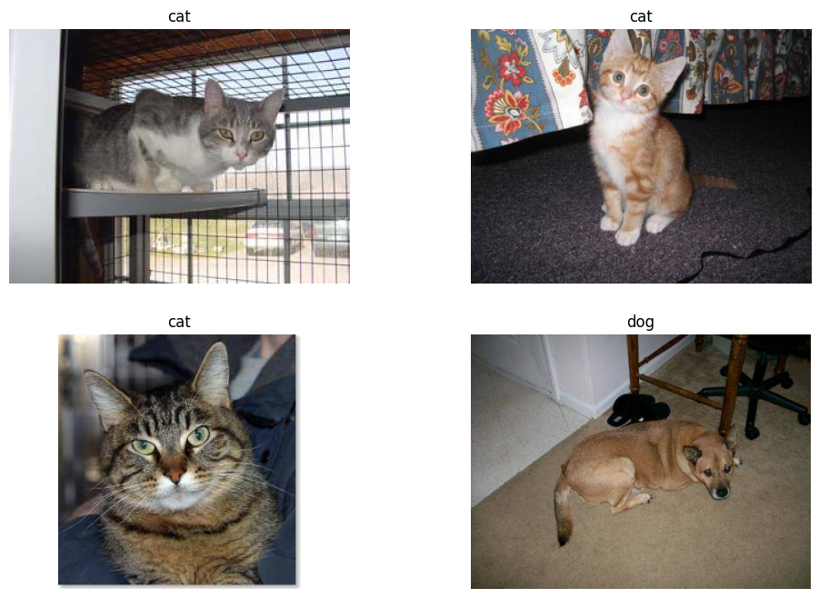

```python
display_images(train_df['path'].tolist())
```

#### Display images from test directories

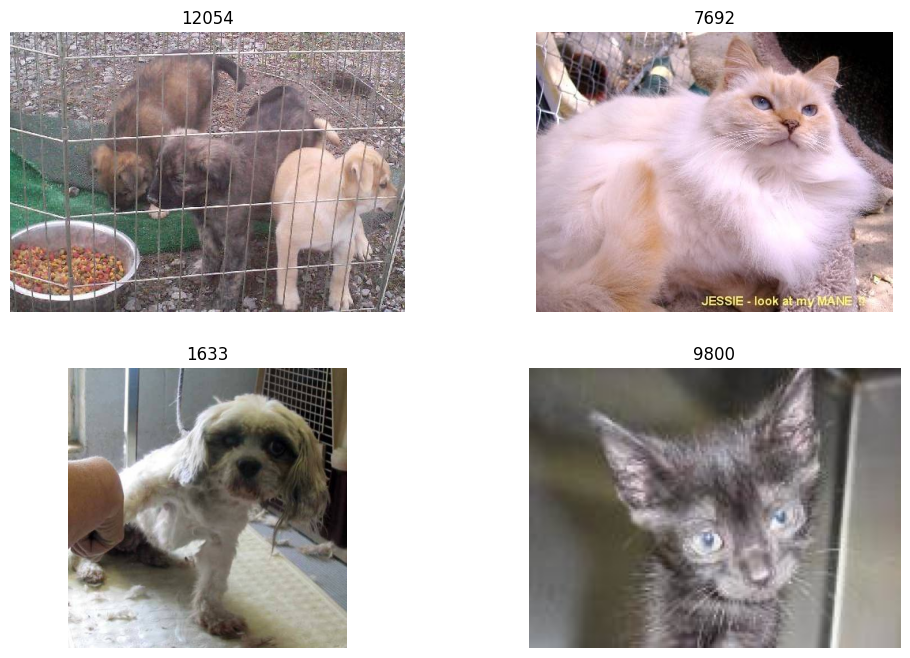

```python
display_images(test_df['path'].tolist())
```

#### Count number of images in each category

```python
cat_count_train = len([filename for filename in os.listdir(train_data) if filename.startswith('cat')])
dog_count_train = len([filename for filename in os.listdir(train_data) if filename.startswith('dog')])
cat_count_train, dog_count_train
```

```
(12500, 12500)
```

#### Plotting the counts

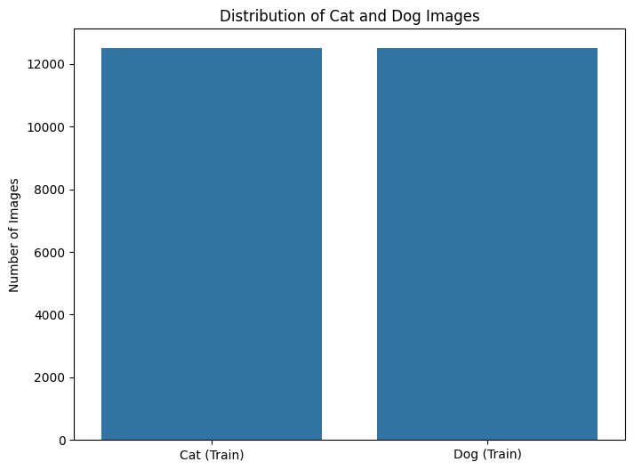

```python
plt.figure(figsize=(8, 6))
sns.barplot(x=['Cat (Train)', 'Dog (Train)'],
            y=[cat_count_train, dog_count_train])
plt.title('Distribution of Cat and Dog Images')
plt.ylabel('Number of Images')
plt.show()
```

It can be seen from graphs and above count that the data in training set is equally distributed for both dog and cat.

#### Plotting the distributions of heights and width of images

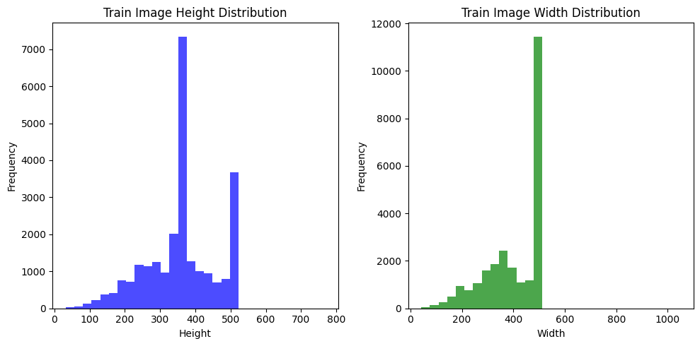

```python
train_sizes = np.array(train_df[['height', 'width']])

plt.figure(figsize=(10, 5))

plt.subplot(1, 2, 1)
plt.hist(train_sizes[:, 0], bins=30, color='blue', alpha=0.7)
plt.title('Train Image Height Distribution')
plt.xlabel('Height')
plt.ylabel('Frequency')

plt.subplot(1, 2, 2)
plt.hist(train_sizes[:, 1], bins=30, color='green', alpha=0.7)
plt.title('Train Image Width Distribution')
plt.xlabel('Width')
plt.ylabel('Frequency')

plt.tight_layout()
plt.show()
```

#### Exploring minimum and maximum height for images in given train and test data

The data displays image heights in the train dataset. It shows more images between 200-400 pixels, with fewer below 200 pixels. Most images fall within the 200-600 pixel range.

- The narrowest images are 42 pixels, and the widest reach 1050 pixels.
- The shortest images are 32 pixels, and the tallest reach 768 pixels.s.

#### Image specific EDA

```python
# Randomly select an index
random_index = random.randint(0, len(train_df) - 1)

# Get the path and label of the randomly selected image
random_image_path = train_df.loc[random_index, 'path']
random_image_label = train_df.loc[random_index, 'label']

# Load the image using PIL
image = Image.open(random_image_path)

# Convert PIL image to numpy array
image_array = np.array(image)
```

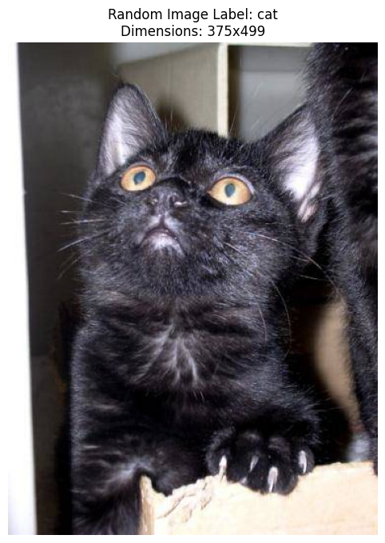

```python
# Visualize the image
plt.figure(figsize=(8, 8))
plt.imshow(image_array)
plt.title(f"Random Image Label: {random_image_label}\nDimensions: {image_array.shape[1]}x{image_array.shape[0]}")
plt.axis('off')
plt.show()
```

```python
# Image dimensions
print(f"Image dimensions: {image_array.shape}")
```

```
Image dimensions: (499, 375, 3)
```

```python
# Descriptive statistics of pixel values
print("Descriptive statistics of pixel values:")
print(f"Min pixel value: {np.min(image_array)}")
print(f"Max pixel value: {np.max(image_array)}")
print(f"Mean pixel value: {np.mean(image_array)}")
print(f"Standard deviation of pixel values: {np.std(image_array)}")
```

```
Descriptive statistics of pixel values:
Min pixel value: 0
Max pixel value: 255
Mean pixel value: 87.99580850590068
Standard deviation of pixel values: 74.18487122973204
```

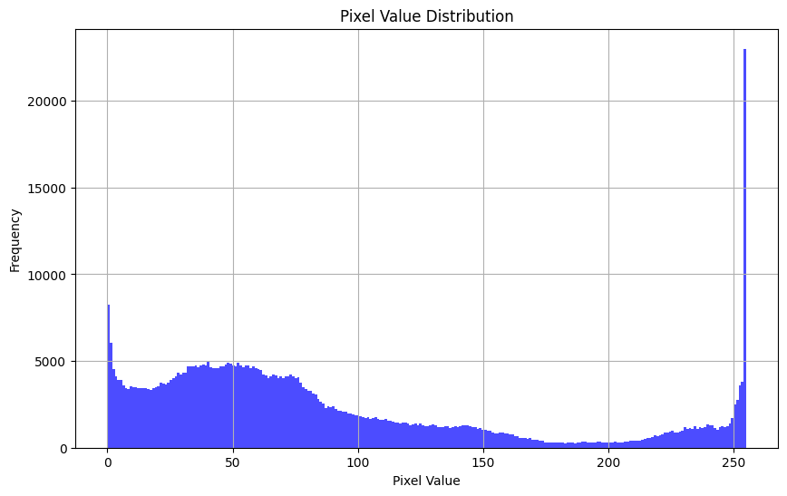

```python
# Pixel value distribution
plt.figure(figsize=(10, 6))
plt.hist(image_array.ravel(), bins=256, color='blue', alpha=0.7)
plt.title('Pixel Value Distribution')
plt.xlabel('Pixel Value')
plt.ylabel('Frequency')
plt.grid(True)
plt.show()
```

# Preprocess data

#### Function to resize image to 32x32 pixels

We are resizing images to 32x32 pixels as VGG16 model expects images in size (32x32). Also minimum height of imgaes have in dataset is 32 pixels.

```python
# Setting path for resized images
train_img_resized_path = './data/resized/train/'
test_img_resized_path = './data/resized/test/'

# Creating directories if does not exist
os.makedirs(train_img_resized_path, exist_ok=True)
os.makedirs(test_img_resized_path, exist_ok=True)
```

```python
def resize_images(image_paths, image_names, output_folder, new_size=(32, 32)):

    resized_paths = []

    for index, image_path in enumerate(image_paths):
        resized_path = os.path.join(output_folder, image_names.iloc[index])
        resized_paths.append(resized_path)

        # Check if the resized image already exists
        if os.path.exists(resized_path):
            continue

        image = Image.open(image_path)
        resized_image = image.resize(new_size)
        resized_image.save(resized_path)

    return resized_paths
```

#### Adding new values and paths to the dataframe

```python
train_df['path_resized'] = resize_images(train_df['path'], train_df['name'], train_img_resized_path)
train_df['height_resized'] = 32
train_df['width_resized'] = 32
train_df.head()
```

|  | path | name | width | height | label | path_resized | height_resized | width_resized |
| --- | --- | --- | --- | --- | --- | --- | --- | --- |
| 0 | ./data/train/cat.0.jpg | cat.0.jpg | 500 | 374 | cat | ./data/resized/train/cat.0.jpg | 32 | 32 |
| 1 | ./data/train/cat.1.jpg | cat.1.jpg | 300 | 280 | cat | ./data/resized/train/cat.1.jpg | 32 | 32 |
| 2 | ./data/train/cat.10.jpg | cat.10.jpg | 489 | 499 | cat | ./data/resized/train/cat.10.jpg | 32 | 32 |
| 3 | ./data/train/cat.100.jpg | cat.100.jpg | 403 | 499 | cat | ./data/resized/train/cat.100.jpg | 32 | 32 |
| 4 | ./data/train/cat.1000.jpg | cat.1000.jpg | 150 | 149 | cat | ./data/resized/train/cat.1000.jpg | 32 | 32 |

```python
test_df['path_resized'] = resize_images(test_df['path'], test_df['name'], test_img_resized_path)
test_df['height_resized'] = 32
test_df['width_resized'] = 32
test_df.head()
```

|  | path | name | width | height | path_resized | height_resized | width_resized |
| --- | --- | --- | --- | --- | --- | --- | --- |
| 0 | ./data/test/1.jpg | 1.jpg | 381 | 499 | ./data/resized/test/1.jpg | 32 | 32 |
| 1 | ./data/test/10.jpg | 10.jpg | 500 | 374 | ./data/resized/test/10.jpg | 32 | 32 |
| 2 | ./data/test/100.jpg | 100.jpg | 499 | 343 | ./data/resized/test/100.jpg | 32 | 32 |
| 3 | ./data/test/1000.jpg | 1000.jpg | 288 | 499 | ./data/resized/test/1000.jpg | 32 | 32 |
| 4 | ./data/test/10000.jpg | 10000.jpg | 467 | 499 | ./data/resized/test/10000.jpg | 32 | 32 |

#### Encoding labels for model training

> REASON: Models only understand numerical data not test

```python
train_df['label_bin'] = train_df['label'].apply(lambda x: 0 if x.lower() == 'cat' else 1)
```

#### Converting image data to numpy array

We are creating function that uses out preprocessed images and convert them to a numpy array saving values of images in array. We will also normalize pixel values by dividing by 255 as pixel values are stored from 0-255.

```python
def image_to_list(df):
    X = []
    for index, row in df.iterrows():
        img = load_img(row['path_resized'])
        img_array = img_to_array(img)

        # Normalize pixel values
        img_array /= 255.0

        X.append(img_array)

    return np.array(X)
```

#### Determining dependent and independent variables

```python
X = image_to_list(train_df)
Y = np.array(train_df['label_bin'])
```

#### Split data into train and test sets

We will split data in train, validation and testing samples in ration 70:15:15 resp. We will train model with training dataset, use validation samples to evaluate model perfomrmance and test data to test model.

```python
X_train, X_temp, Y_train, Y_temp = train_test_split(X, Y, stratify= Y, test_size=0.3)
X_test, X_val, Y_test, Y_val = train_test_split(X_temp, Y_temp, stratify = Y_temp, test_size=0.5)
X_train.shape, Y_train.shape, X_test.shape, Y_test.shape, X_val.shape, Y_val.shape
```

```
((17500, 32, 32, 3),
 (17500,),
 (3750, 32, 32, 3),
 (3750,),
 (3750, 32, 32, 3),
 (3750,))
```

> NOTE: We are creating out test samples from out training dataset only as out test data does not have labels hence can not be used to get model performance

# Modelling

#### Defining and compiling the CNN model

```python
cnn_model = tf.keras.Sequential([
    tf.keras.layers.Conv2D(32, (3, 3), activation='relu', input_shape=(32, 32, 3)),
    tf.keras.layers.MaxPooling2D((2, 2)),
    tf.keras.layers.Conv2D(64, (3, 3), activation='relu'),
    tf.keras.layers.MaxPooling2D((2, 2)),
    tf.keras.layers.Conv2D(64, (3, 3), activation='relu'),
    tf.keras.layers.Flatten(),
    tf.keras.layers.Dense(64, activation='relu'),
    tf.keras.layers.Dense(1, activation='sigmoid')
])

cnn_model.compile(
    optimizer=Adam(),
    loss='binary_crossentropy',
    metrics=['accuracy']
)
```

#### Define the ModelCheckpoint callback

```python
cnn_checkpoint = ModelCheckpoint(
    "./best_model_cnn.h5",
    monitor='val_accuracy',
    verbose=1,
    save_best_only=True,
    mode='max'
)
```

#### Train the model with callbacks

```python
cnn_history = cnn_model.fit(
    X_train,
    Y_train,
    epochs=20,
    batch_size=32,
    validation_data=(X_val, Y_val),
    callbacks=[cnn_checkpoint]
)
```

```
Epoch 1: val_accuracy improved from -inf to 0.72640, saving model to .\best_model_cnn.h5
Epoch 2: val_accuracy did not improve from 0.72640
Epoch 3: val_accuracy improved from 0.72640 to 0.74640, saving model to .\best_model_cnn.h5
Epoch 4: val_accuracy improved from 0.74640 to 0.77707, saving model to .\best_model_cnn.h5
Epoch 5: val_accuracy did not improve from 0.77707
Epoch 6: val_accuracy improved from 0.77707 to 0.80080, saving model to .\best_model_cnn.h5
Epoch 7: val_accuracy did not improve from 0.80080
Epoch 8: val_accuracy did not improve from 0.80080
Epoch 9: val_accuracy did not improve from 0.80080
Epoch 10: val_accuracy improved from 0.80080 to 0.80853, saving model to .\best_model_cnn.h5
Epoch 11: val_accuracy did not improve from 0.80853
Epoch 12: val_accuracy did not improve from 0.80853
Epoch 13: val_accuracy did not improve from 0.80853
Epoch 14: val_accuracy did not improve from 0.80853
Epoch 15: val_accuracy did not improve from 0.80853
Epoch 16: val_accuracy did not improve from 0.80853
Epoch 17: val_accuracy did not improve from 0.80853
Epoch 18: val_accuracy did not improve from 0.80853
Epoch 19: val_accuracy did not improve from 0.80853
Epoch 20: val_accuracy did not improve from 0.80853
```

#### Plot training and validation accuracy adn loss for CNN model

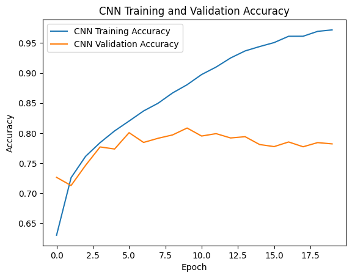

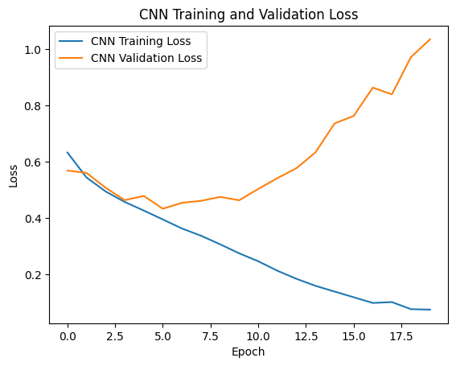

```python
# Plot accuracy for CNN model
plt.plot(cnn_history.history['accuracy'], label='CNN Training Accuracy')
plt.plot(cnn_history.history['val_accuracy'], label='CNN Validation Accuracy')
plt.xlabel('Epoch')
plt.ylabel('Accuracy')
plt.title('CNN Training and Validation Accuracy')
plt.legend()
plt.show()

# Plot loss for CNN model
plt.plot(cnn_history.history['loss'], label='CNN Training Loss')
plt.plot(cnn_history.history['val_loss'], label='CNN Validation Loss')
plt.xlabel('Epoch')
plt.ylabel('Loss')
plt.title('CNN Training and Validation Loss')
plt.legend()
plt.show()
```

The graphs illustrate the training and validation accuracy of a convolutional neural network (CNN) model. The training accuracy consistently increases to above 0.95, indicating good performance on training data. However, the validation accuracy fluctuates between 0.70-0.80, suggesting possible overfitting.

#### Define adn compile VGG16 model with fine-tuning

```python
base_model = VGG16(weights='imagenet', include_top=False, input_shape=(32, 32, 3))
for layer in base_model.layers:
    layer.trainable = False
x = base_model.output
x = GlobalAveragePooling2D()(x)
x = Dense(128, activation='relu')(x)
predictions = Dense(1, activation='sigmoid')(x)
vgg16_model = Model(inputs=base_model.input, outputs=predictions)

# Compile the model
vgg16_model.compile(
    optimizer=Adam(),
    loss='binary_crossentropy',
    metrics=['accuracy']
)
```

#### Creating VGG model check points

```python
vgg_checkpoint = ModelCheckpoint(
    "best_model_VGG16.h5",
    monitor='val_accuracy',
    verbose=1,
    save_best_only=True,
    mode='max'
)
```

#### Retrining VGG16 model

```python
vgg16_history = vgg16_model.fit(
    X_train,
    Y_train,
    epochs=20,
    batch_size=32,
    validation_data=(X_val, Y_val),
    callbacks=[vgg_checkpoint]
)
```

```
Epoch 1: val_accuracy improved from -inf to 0.72240, saving model to best_model_VGG16.h5
Epoch 2: val_accuracy improved from 0.72240 to 0.72827, saving model to best_model_VGG16.h5
Epoch 3: val_accuracy improved from 0.72827 to 0.73707, saving model to best_model_VGG16.h5
Epoch 4: val_accuracy did not improve from 0.73707
Epoch 5: val_accuracy did not improve from 0.73707
Epoch 6: val_accuracy did not improve from 0.73707
Epoch 7: val_accuracy did not improve from 0.73707
Epoch 8: val_accuracy improved from 0.73707 to 0.74320, saving model to best_model_VGG16.h5
Epoch 9: val_accuracy did not improve from 0.74320
Epoch 10: val_accuracy did not improve from 0.74320
Epoch 11: val_accuracy did not improve from 0.74320
Epoch 12: val_accuracy did not improve from 0.74320
Epoch 13: val_accuracy did not improve from 0.74320
Epoch 14: val_accuracy did not improve from 0.74320
Epoch 15: val_accuracy did not improve from 0.74320
Epoch 16: val_accuracy did not improve from 0.74320
Epoch 17: val_accuracy did not improve from 0.74320
Epoch 18: val_accuracy did not improve from 0.74320
Epoch 19: val_accuracy did not improve from 0.74320
Epoch 20: val_accuracy did not improve from 0.74320
```

#### Plot training and validation accuracy and loss for VGG16 model

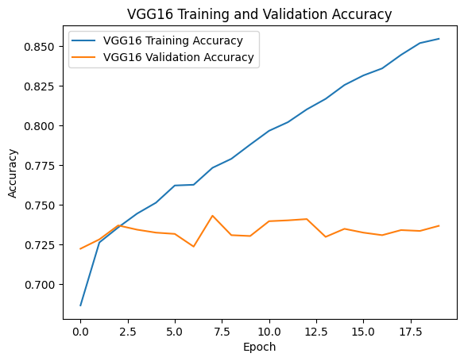

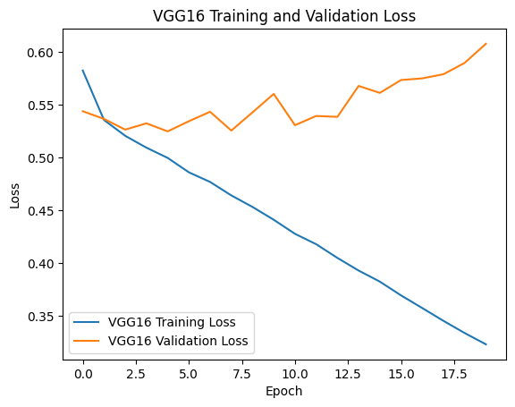

```python
# Plot accuracy for VGG16 model
plt.plot(vgg16_history.history['accuracy'], label='VGG16 Training Accuracy')
plt.plot(vgg16_history.history['val_accuracy'], label='VGG16 Validation Accuracy')
plt.xlabel('Epoch')
plt.ylabel('Accuracy')
plt.title('VGG16 Training and Validation Accuracy')
plt.legend()
plt.show()

# Plot loss for VGG16 model
plt.plot(vgg16_history.history['loss'], label='VGG16 Training Loss')
plt.plot(vgg16_history.history['val_loss'], label='VGG16 Validation Loss')
plt.xlabel('Epoch')
plt.ylabel('Loss')
plt.title('VGG16 Training and Validation Loss')
plt.legend()
plt.show()
```

# Model Evaluations

#### Load the best versions of the models

```python
cnn_best_model = load_model("./best_model_cnn.h5")
vgg16_best_model = load_model("./best_model_VGG16.h5")
```

#### Predictions

```python
Y_pred_cnn = cnn_best_model.predict(X_test).round()
Y_pred_vgg16 = vgg16_best_model.predict(X_test).round()
```

#### Evaluate the models on the test data

```python
cnn_scores = cnn_best_model.evaluate(X_test, Y_test, verbose=0)
vgg16_scores = vgg16_best_model.evaluate(X_test, Y_test, verbose=0)
```

#### Classification report

```python
cnn_report = classification_report(Y_test, Y_pred_cnn, output_dict=True)
vgg16_report = classification_report(Y_test, Y_pred_vgg16, output_dict=True)
```

#### Create the model summary dataframe

```python
model_summary = pd.DataFrame({
    'Model': ['CNN', 'VGG16'],
    'Accuracy': [cnn_scores[1], vgg16_scores[1]],
    'Precision': [cnn_report['1']['precision'], vgg16_report['1']['precision']],
    'Recall': [cnn_report['1']['recall'], vgg16_report['1']['recall']],
    'F1-score': [cnn_report['1']['f1-score'], vgg16_report['1']['f1-score']]
})
```

```python
model_summary
```

|  | Model | Accuracy | Precision | Recall | F1-score |
| --- | --- | --- | --- | --- | --- |
| 0 | CNN | 0.780800 | 0.779607 | 0.782933 | 0.781267 |
| 1 | VGG16 | 0.734133 | 0.724438 | 0.755733 | 0.739755 |

#### Plot confusion matrices

```python
cnn_conf_matrix = confusion_matrix(Y_test, Y_pred_cnn)
vgg16_conf_matrix = confusion_matrix(Y_test, Y_pred_vgg16)
```

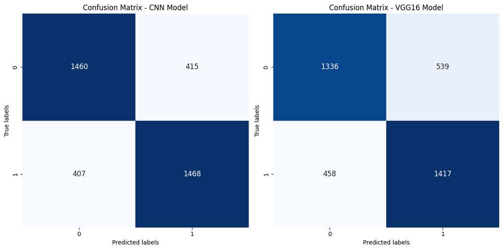

```python
plt.figure(figsize=(12, 6))

plt.subplot(1, 2, 1)
plt.title("Confusion Matrix - CNN Model")
sns.heatmap(cnn_conf_matrix, annot=True, fmt='d', cmap='Blues', cbar=False, annot_kws={"fontsize":12})
plt.xlabel("Predicted labels")
plt.ylabel("True labels")

plt.subplot(1, 2, 2)
plt.title("Confusion Matrix - VGG16 Model")
sns.heatmap(vgg16_conf_matrix, annot=True, fmt='d', cmap='Blues', cbar=False, annot_kws={"fontsize":12})
plt.xlabel("Predicted labels")
plt.ylabel("True labels")

plt.tight_layout()
plt.show()
```

#### Compute precision-recall curve

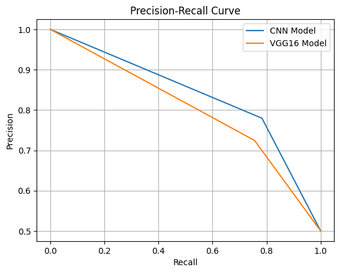

```python
cnn_precision, cnn_recall, _ = precision_recall_curve(Y_test, Y_pred_cnn)
vgg16_precision, vgg16_recall, _ = precision_recall_curve(Y_test, Y_pred_vgg16)

# Plot precision-recall curve
plt.plot(cnn_recall, cnn_precision, label='CNN Model')
plt.plot(vgg16_recall, vgg16_precision, label='VGG16 Model')
plt.xlabel('Recall')
plt.ylabel('Precision')
plt.title('Precision-Recall Curve')
plt.legend()
plt.grid(True)
plt.show()
```

#### Display images where CNN model failed

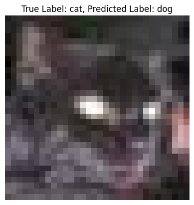

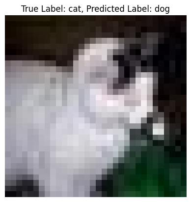

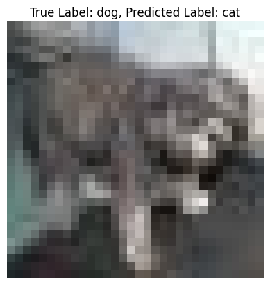

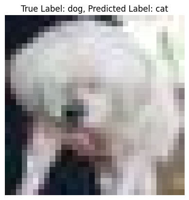

```python
# Get predictions from the CNN model
Y_pred_cnn = (Y_pred_cnn > 0.5).astype('int').flatten()  # Convert probabilities to binary predictions

# Find misclassifications for CNN model
misclassified_indices_cnn = np.where(Y_pred_cnn != Y_test)[0]

selected_indices_cnn = misclassified_indices_cnn[:4]

# Visualize misclassified images for CNN model
for index in selected_indices_cnn:
    img = X_test[index]
    true_label = "cat" if Y_test[index] == 0 else "dog"
    predicted_label = "cat" if Y_pred_cnn[index] == 0 else "dog"
    plt.imshow(img)
    plt.title(f"True Label: {true_label}, Predicted Label: {predicted_label}")
    plt.axis('off')
    plt.show()
```

#### Display images where VGG16 model failed

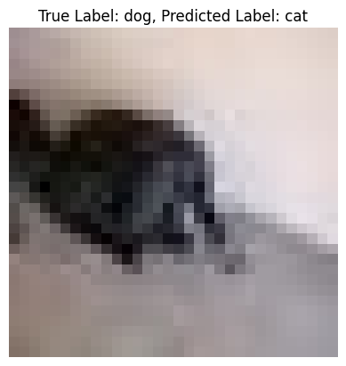

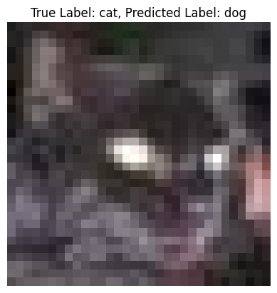

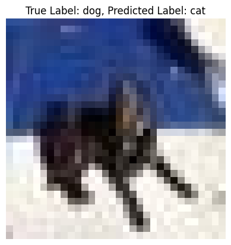

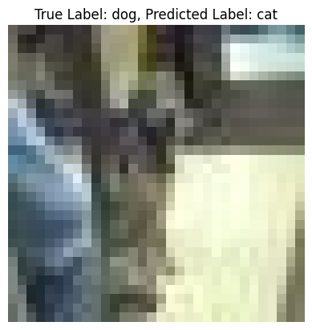

```python
# Get predictions from the VGG16 model
Y_pred_vgg16 = (Y_pred_vgg16 > 0.5).astype('int').flatten()  # Convert probabilities to binary predictions

# Find misclassifications for VGG16 model
misclassified_indices_vgg16 = np.where(Y_pred_vgg16 != Y_test)[0]

selected_indices_vgg16 = misclassified_indices_vgg16[:4]

# Visualize misclassified images for VGG16 model
for index in selected_indices_vgg16:
    img = X_test[index]
    true_label = "cat" if Y_test[index] == 0 else "dog"
    predicted_label = "cat" if Y_pred_vgg16[index] == 0 else "dog"
    plt.imshow(img)
    plt.title(f"True Label: {true_label}, Predicted Label: {predicted_label}")
    plt.axis('off')
    plt.show()
```

# Conclusions

#### Insights based on above evaluations of best moodels

The comparison provided is between two image classification models, CNN (Convolutional Neural Network) and VGG16. The table summarizes various metrics for each model:

Based on the confusion matrix, the CNN model achieved 2928 correct classifications compared to VGG16's 2753. This translates to the CNN model misclassifying 822 images versus a much higher 997 for VGG16. Overall, the CNN model seems significantly less confused by the data set.

The CNN model also appears to outperform the VGG16 model in terms of both precision and recall based on the precision-recall curve.

#### Overall conclusion is that our CNN model is better suited for classification of the providded dataset and continuously outperform VGG16 Model.